## Load Libraries

```r
library(tidyverse)
library(skimr)
library(zoo)
library(car)
```

```r
library(corrplot)
library(rpart)
library(here)
```

## Load datasets

```r
data <- read.csv(here('oil_generation_prediction.csv'))
str(data)
```

```
## 'data.frame':    6925 obs. of  14 variables:
##  $ PRODUCTION.DATE              : chr  "07/04/2014 00:00" "08/04/2014 00:00" "09/04/2014 00:00" "10/04/2014 00:00" ...
##  $ Field.Name                   : chr  "DSEAT" "DSEAT" "DSEAT" "DSEAT" ...
##  $ WELL_BORE_CODE               : chr  "DSEAT-001-F-1 C" "DSEAT-001-F-1 C" "DSEAT-001-F-1 C" "DSEAT-001-F-1 C" ...
##  $ N_WELL_BORE_CODE             : int  105 105 105 105 105 105 105 105 105 105 ...
##  $ WellBore.Name                : chr  "001-F-1 C" "001-F-1 C" "001-F-1 C" "001-F-1 C" ...
##  $ FLOW_KIND                    : chr  "production" "production" "production" "production" ...
##  $ WELL_TYPE                    : chr  "OP" "OP" "OP" "OP" ...
##  $ Downhole.Pressure..PSI.      : num  0 0 0 0 4500 ...
##  $ Downhole.Temperature..Kelvin.: num  273 273 273 273 370 ...
##  $ Average.Tubing.Pressure      : num  0 0 0 0 4021 ...
##  $ Annulus.Pressure..PSI.       : num  0 0 0 0 0 0 0 0 0 0 ...
##  $ AVG.WHP..PSI.                : num  0 0 0 0 480 ...
##  $ Choke.Size                   : num  0 0 0 0 33.1 ...
##  $ Oil.Production..stb.day.     : num  0 0 0 0 0 0 0 0 0 0 ...
```

There are 14 variables. The last one “Oil.Production..stb.day.” is the target variable.

We create a new dataframe for all the predictors, dropping field name and flow kind because they have a single value so they add nothing to the model.

```r
X <- data[1:13] %>% select(-Field.Name, -FLOW_KIND)
y <- (data[14])
```

Next we rename the variables to make them easier to work with

```r
col_names <- c(
            "production_date",
            "well_bore_code",
            "n_well_bore_code",
            "well_bore_name",
            "well_type",
            "downward_pressure_psi",
            "downhole_temp_kelvin",
            "avg_tubing_pressure",
            "annulus_pressure_psi",
            "avg_whp_psi",
            "choke_size"
)
colnames(X) <- col_names
colnames(X)
```

```
##  [1] "production_date"       "well_bore_code"        "n_well_bore_code"
##  [4] "well_bore_name"        "well_type"             "downward_pressure_psi"
##  [7] "downhole_temp_kelvin"  "avg_tubing_pressure"   "annulus_pressure_psi"
## [10] "avg_whp_psi"           "choke_size"
```

these variables are the same with well_bore_code so we drop them

```r
X <- X %>% select(-well_bore_name, -n_well_bore_code)
```

We also note that well_type has the same value for all observations except one. Thus, it is equivalent to having only one value across all variables. We will also drop it from the model

```r
table(X$well_type)
```

```
##
##   OP   WI
## 6924    1
```

```r
X<- X %>% select(-well_type)
```

The production date is in character format so we convert production date into date

```r
X$production_date <- as.Date(X$production_date, format = "%d/%m/%Y")
```

Missing values in choke size variable # Count the number of rows with missing values in the choke size variable

```r
missing_rows <- sum(is.na(X$choke_size))
missing_rows
```

```
## [1] 6
```

There are only six values with missing values on the choke.size variable. We don’t drop them so we don’t want to mess with the time series We can consider imputing them based on: i. the values on the days before or after them. ii. the average values

The first will be best if choke.size shows time dependency. Let’s plot the time series to see # Plotting the line chart

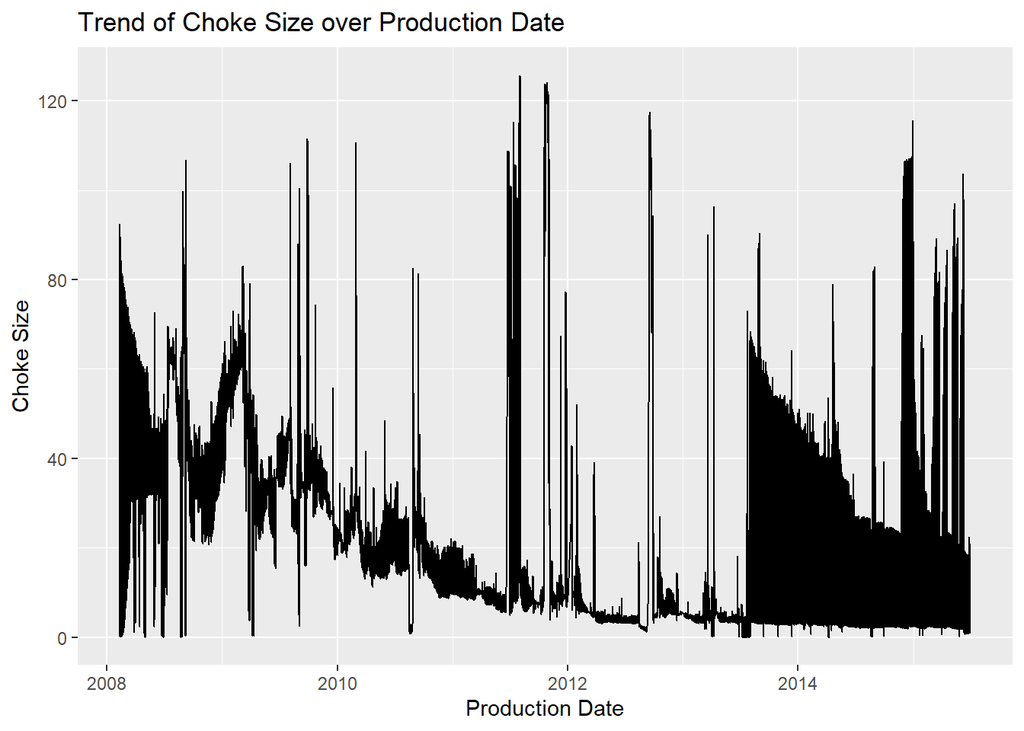

```r
ggplot(X, aes(x = production_date, y = choke_size)) +
    geom_line() +
    labs(x = "Production Date", y = "Choke Size") +
    ggtitle("Trend of Choke Size over Production Date")
```

The choke_size variable shows a visible trend over time (which is also similar to the trend of oil production) # Impute missing values for choke_size with 7-day rolling average

```r
X$choke_size_rolling <- zoo::rollmeanr(X$choke_size, k = 7, fill = NA, align = "right", na.rm = TRUE)
X <- X %>%
  mutate(choke_size = ifelse(is.na(choke_size), choke_size_rolling, choke_size))
X <- X %>% select(-choke_size_rolling)
sum(is.na(X$choke_size))
```

```
## [1] 0
```

We establish a baseline by running a regression model on the variables as is. To do this we combine the variables in one df

```r
all_variables <- cbind(X,y)
colnames(all_variables)[ncol(all_variables)] <- "y" # Rename target to y
model_all_variables <- lm(y ~ . , data = all_variables)
summary(model_all_variables)
```

```
##
## Call:
## lm(formula = y ~ ., data = all_variables)
##
## Residuals:
##      Min       1Q   Median       3Q      Max
## -22452.7  -1609.2   -453.1   1129.5  24490.0
##
## Coefficients:
##                                  Estimate Std. Error t value Pr(>|t|)
## (Intercept)                    16222.3989  3665.8245   4.425 9.78e-06 ***
## production_date                   -6.2313     0.1236 -50.401  < 2e-16 ***
## well_bore_codeDSEAT-001-F-11 H  2013.7343   299.4083   6.726 1.89e-11 ***
## well_bore_codeDSEAT-001-F-12 H  6482.1728   401.0228  16.164  < 2e-16 ***
## well_bore_codeDSEAT-001-F-14 H  1346.0670   306.3757   4.394 1.13e-05 ***
## well_bore_codeDSEAT-001-F-15 D -5247.6391   304.2722 -17.247  < 2e-16 ***
## downward_pressure_psi             -4.8975     0.2564 -19.104  < 2e-16 ***
## downhole_temp_kelvin             272.8809     7.9795  34.198  < 2e-16 ***
## avg_tubing_pressure               -0.8972     0.2039  -4.401 1.09e-05 ***
## annulus_pressure_psi               2.1522     0.5462   3.940 8.23e-05 ***
## avg_whp_psi                       11.9355     0.4447  26.840  < 2e-16 ***
## choke_size                      -159.4879     7.4139 -21.512  < 2e-16 ***
## ---
## Signif. codes:  0 '***' 0.001 '**' 0.01 '*' 0.05 '.' 0.1 ' ' 1
##
## Residual standard error: 4159 on 6913 degrees of freedom
## Multiple R-squared:  0.7834, Adjusted R-squared:  0.783
## F-statistic:  2272 on 11 and 6913 DF,  p-value: < 2.2e-16
```

##Feature engineering Time factor we explore what time trends we can find to include another time variable in our model

First we visualize the entire time series to see if there are any visible trends

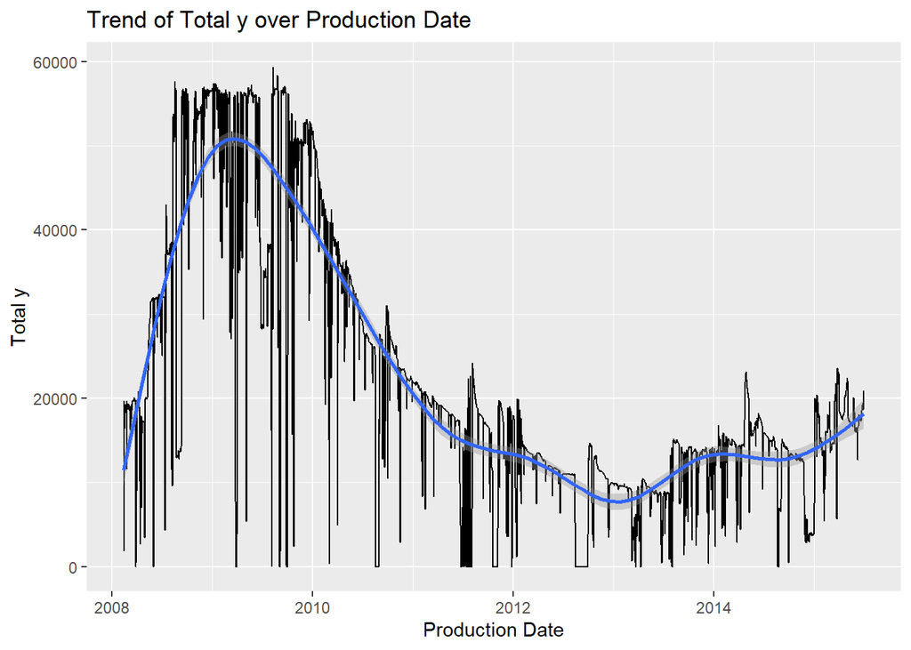

```r
agg_production_date <- all_variables %>%
    group_by(production_date) %>%
    summarise(total_y = sum(y))

ggplot(agg_production_date, aes(x = production_date, y = total_y)) +
    geom_line() +
    geom_smooth() +
    labs(x = "Production Date", y = "Total y") +
    ggtitle("Trend of Total y over Production Date")
```

Even though it’s quite noisy we can see a trend over time in y. Thus, we notice two things: 1. the model may be autoregressive, and a lag variable should be predictive of the next value 2. There is no linear relationship over time. Instead the trend looks cubic

```r
# Create a lag variable for y
all_variables <- all_variables %>%
  arrange(production_date) %>%
  group_by(well_bore_code) %>%
  mutate(lag_y = lag(y, order_by = production_date)) %>%
  ungroup()
```

# Create year_month, month, day, and weekday variables from production_date

```r
all_variables <- all_variables %>%
    mutate(
        year_month = format(production_date, "%Y%m"),
        year = year(production_date),
        month = month(production_date),
        day = day(production_date),
        weekday = wday(production_date, label = TRUE)
    )

# Aggregate y by year_month, month, day, and weekday
agg_year_month <- all_variables %>%
    group_by(year_month) %>%
    summarise(total_y = sum(y))
agg_month <- all_variables %>%
    group_by(month, year) %>%
    summarise(total_y = sum(y))
agg_weekday <- all_variables %>%
    group_by(weekday) %>%
    summarise(total_y = sum(y))
agg_day <- all_variables %>%
    group_by(day, month) %>%
    summarise(total_y = sum(y))
```

[output not shown]

Visualize trends # Create line charts Viewing the total oil production in each month

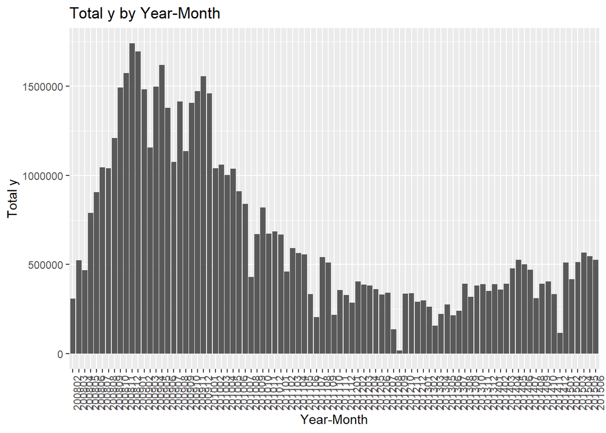

```r
ggplot(agg_year_month, aes(x = year_month, y = total_y)) +
    geom_bar(stat = "identity") +
    labs(x = "Year-Month", y = "Total y") +
    ggtitle("Total y by Year-Month") +
    theme(axis.text.x = element_text(angle = 90, hjust = 1))
```

Visualizing monthly trends for each year to scan for patterns

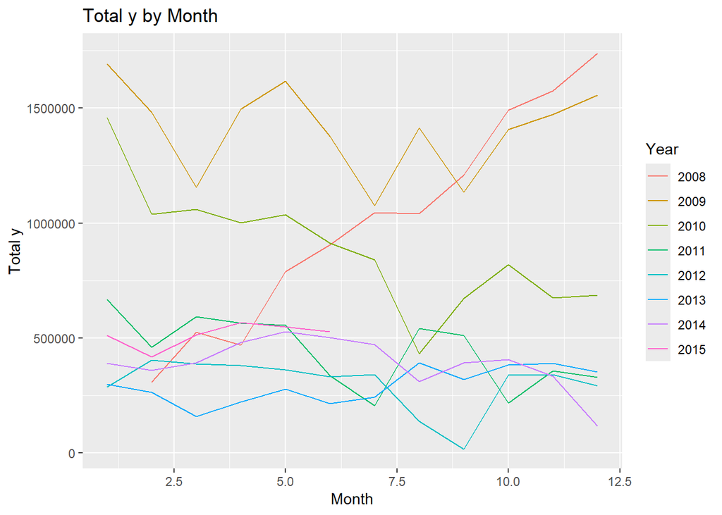

```r
ggplot(agg_month, aes(x = month, y = total_y, color = factor(year))) +
    geom_line() +
    labs(x = "Month", y = "Total y") +
    ggtitle("Total y by Month") +
    scale_color_discrete(name = "Year")
```

We can see that there is no trend by month that is constant year on year

Visualizing daily trends over each month

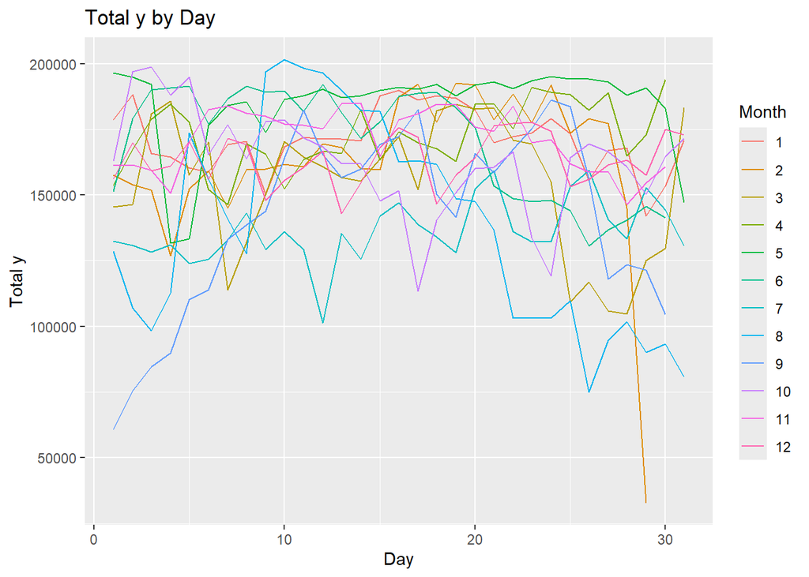

```r
ggplot(agg_day, aes(x = day, y = total_y, color = factor(month))) +
    geom_line() +
    labs(x = "Day", y = "Total y") +
    ggtitle("Total y by Day") +
    scale_color_discrete(name = "Month")
```

Visualizing trend by weekday

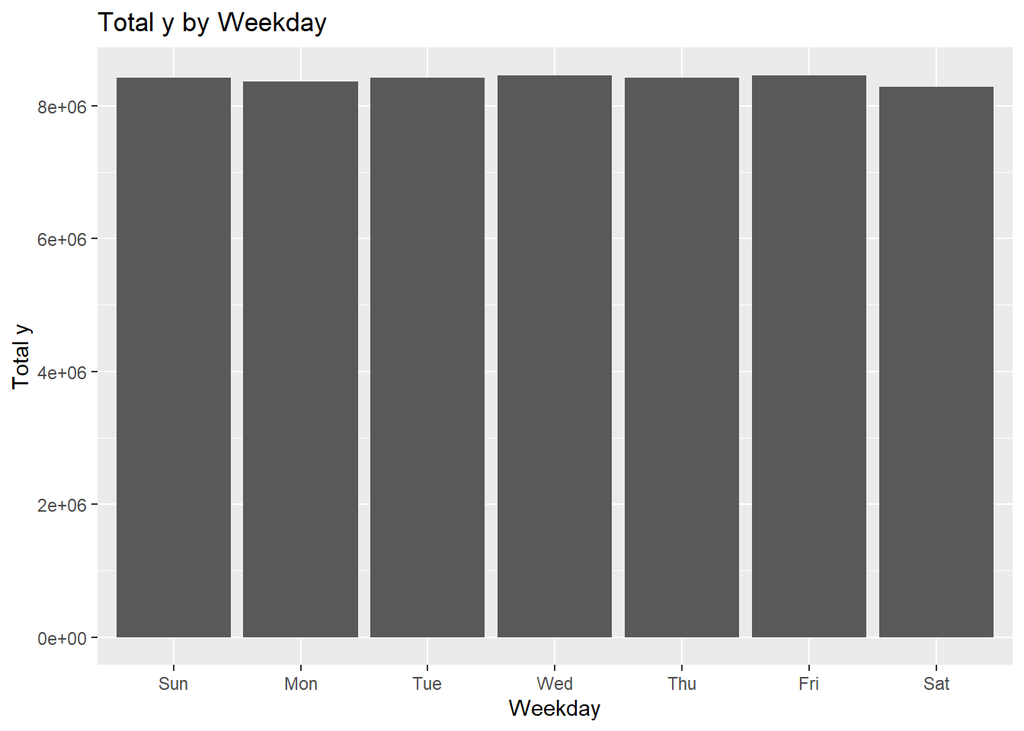

```r
ggplot(agg_weekday, aes(x = weekday, y = total_y)) +
    geom_bar(stat = "identity") +
    labs(x = "Weekday", y = "Total y") +
    ggtitle("Total y by Weekday")
```

For all time periods, there is no particular trend. Hence, we can conclude that there is no cyclical component to the time series

Hence we remove time-related variables

```r
# Remove the time-related variables
all_variables <- all_variables %>% select(-year_month, -month, -day, -year, -weekday)
str(all_variables)
```

```
## tibble [6,925 × 10] (S3: tbl_df/tbl/data.frame)
##  $ production_date      : Date[1:6925], format: "2008-02-12" "2008-02-12" ...
##  $ well_bore_code       : chr [1:6925] "DSEAT-001-F-12 H" "DSEAT-001-F-14 H" "DSEAT-001-F-12 H" "DSEAT-001-F-14 H" ...
##  $ downward_pressure_psi: num [1:6925] 4467 0 4394 0 4286 ...
##  $ downhole_temp_kelvin : num [1:6925] 378 273 379 273 379 ...
##  $ avg_tubing_pressure  : num [1:6925] 2918 0 2641 0 2637 ...
##  $ annulus_pressure_psi : num [1:6925] 270 0 239 0 184 ...
##  $ avg_whp_psi          : num [1:6925] 1549 0 1753 0 1649 ...
##  $ choke_size           : num [1:6925] 92.4751 0.0588 89.6201 0.0677 80.1205 ...
##  $ y                    : num [1:6925] 1790 0 11760 0 19651 ...
##  $ lag_y                : num [1:6925] NA NA 1790 0 11760 ...
```

While the model works very well in its current form, we have generally assumed a linear relationship can we get an even higher performance if we are able to approximate non-linear relationships?

Now we evaluate the possibility of non-linear relationships

Time factor We look at the trend of oil production over time once again, which is obviously not a linear relationship.

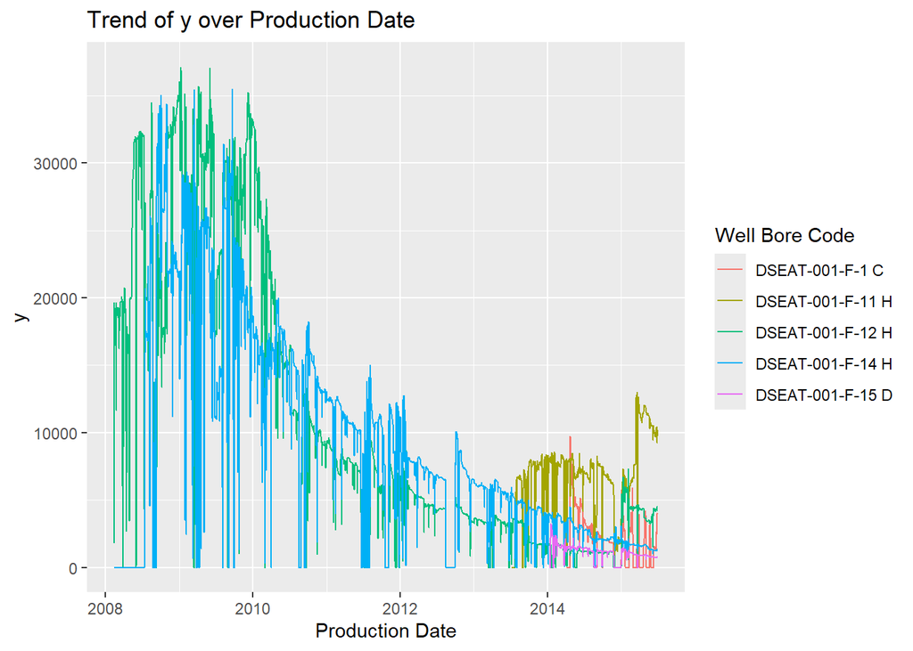

```r
ggplot(all_variables, aes(x = production_date, y = y, color = well_bore_code)) +
    geom_line() +
    labs(x = "Production Date", y = "y") +
    ggtitle("Trend of y over Production Date") +
    scale_color_discrete(name = "Well Bore Code")
```

By visualizing the oil production over time for each well, we notice the drop in production in the two wells from the beginning, before three other wells were added to supplement production This may indicate: i. An interaction effect. The effect of time on oil production volume is well dependent. That is, in the initial stages, wells increase in production till they get to full capacity. However, as the oil reserves depletes, the volume of oil from each well starts to fall Hence we consider introducing an interaction effect between days_from_origin and well_bore_code ii. Also the trend between time and oil production is non linear, so we introduce a quadratic term

```r
# Create days_from_origin variable
all_variables <- all_variables %>%
    arrange(production_date) %>%
    group_by(well_bore_code) %>%
    mutate(days_from_origin = as.numeric(production_date - min(production_date))) %>%
    ungroup()
all_variables <- all_variables %>% select(-production_date)
# Fit the linear regression model with an interaction effect between days_from_origin and well_bore_code
model_interaction <- lm(y ~ . + I(days_from_origin^2) + days_from_origin * well_bore_code, data = all_variables)
summary(model_interaction)
```

```
##
## Call:
## lm(formula = y ~ . + I(days_from_origin^2) + days_from_origin *
##     well_bore_code, data = all_variables)
##
## Residuals:
##      Min       1Q   Median       3Q      Max
## -26224.3   -384.0    -29.1    413.2  23021.2
##
## Coefficients:
##                                                   Estimate Std. Error t value
## (Intercept)                                     -2.047e+04  1.586e+03 -12.910
## well_bore_codeDSEAT-001-F-11 H                   1.160e+03  3.324e+02   3.489
## well_bore_codeDSEAT-001-F-12 H                   5.967e+03  3.410e+02  17.502
## well_bore_codeDSEAT-001-F-14 H                   5.242e+03  3.166e+02  16.557
## well_bore_codeDSEAT-001-F-15 D                  -1.298e+03  3.390e+02  -3.829
## downward_pressure_psi                           -1.228e+00  1.667e-01  -7.370
## downhole_temp_kelvin                             6.383e+01  5.360e+00  11.909
## avg_tubing_pressure                             -5.533e-02  1.276e-01  -0.434
## annulus_pressure_psi                             5.155e-01  3.532e-01   1.460
## avg_whp_psi                                      4.444e+00  2.987e-01  14.874
## choke_size                                      -6.930e+01  4.999e+00 -13.862
## lag_y                                            7.529e-01  7.276e-03 103.477
## days_from_origin                                -3.039e-01  9.263e-01  -0.328
## I(days_from_origin^2)                            6.472e-04  7.307e-05   8.857
## well_bore_codeDSEAT-001-F-11 H:days_from_origin -1.377e+00  1.051e+00  -1.310
## well_bore_codeDSEAT-001-F-12 H:days_from_origin -3.036e+00  9.521e-01  -3.189
## well_bore_codeDSEAT-001-F-14 H:days_from_origin -3.415e+00  9.465e-01  -3.608
## well_bore_codeDSEAT-001-F-15 D:days_from_origin -4.811e-01  1.166e+00  -0.412
##                                                 Pr(>|t|)
## (Intercept)                                      < 2e-16 ***
## well_bore_codeDSEAT-001-F-11 H                  0.000488 ***
## well_bore_codeDSEAT-001-F-12 H                   < 2e-16 ***
## well_bore_codeDSEAT-001-F-14 H                   < 2e-16 ***
## well_bore_codeDSEAT-001-F-15 D                  0.000130 ***
## downward_pressure_psi                           1.91e-13 ***
## downhole_temp_kelvin                             < 2e-16 ***
## avg_tubing_pressure                             0.664514
## annulus_pressure_psi                            0.144451
## avg_whp_psi                                      < 2e-16 ***
## choke_size                                       < 2e-16 ***
## lag_y                                            < 2e-16 ***
## days_from_origin                                0.742828
## I(days_from_origin^2)                            < 2e-16 ***
## well_bore_codeDSEAT-001-F-11 H:days_from_origin 0.190328
## well_bore_codeDSEAT-001-F-12 H:days_from_origin 0.001434 **
## well_bore_codeDSEAT-001-F-14 H:days_from_origin 0.000311 ***
## well_bore_codeDSEAT-001-F-15 D:days_from_origin 0.680026
## ---
## Signif. codes:  0 '***' 0.001 '**' 0.01 '*' 0.05 '.' 0.1 ' ' 1
##
## Residual standard error: 2513 on 6902 degrees of freedom
##   (5 observations deleted due to missingness)
## Multiple R-squared:  0.9209, Adjusted R-squared:  0.9207
## F-statistic:  4730 on 17 and 6902 DF,  p-value: < 2.2e-16
```

Both the interaction effects and days_from_origin^2 are significant Note that the interaction effects are significant for the older wells that have gone full cycle. The newer wells have not yet experienced the entire cycle so the interaction effects are not yet noticeable

##Correlations

Next we analyse the correlations of the numeric variables, and then evaluate the possibility of non-linear relationships

```r
numeric_variables <- all_variables %>% select(downward_pressure_psi,
                                            downhole_temp_kelvin,
                                            avg_tubing_pressure,
                                            annulus_pressure_psi,
                                            avg_whp_psi,
                                            choke_size)
y <- all_variables$y
correlation <- cor(numeric_variables, y)
correlation
```

```
##                              [,1]
## downward_pressure_psi  0.31823232
## downhole_temp_kelvin   0.33966620
## avg_tubing_pressure    0.20394413
## annulus_pressure_psi  -0.09213578
## avg_whp_psi            0.42798796
## choke_size             0.28866339
```

Annulus pressure had the lowest correlation with the target. A regresssion on annulus pressure assuming a quadratic relationship showed a better performance

```r
model_annulus <- lm(y ~ . + I(annulus_pressure_psi^2) + I(days_from_origin^2) + days_from_origin * well_bore_code, data = all_variables)
summary(model_annulus)
```

```
##
## Call:
## lm(formula = y ~ . + I(annulus_pressure_psi^2) + I(days_from_origin^2) +
##     days_from_origin * well_bore_code, data = all_variables)
##
## Residuals:
##      Min       1Q   Median       3Q      Max
## -26283.3   -379.3    -49.4    437.4  22996.3
##
## Coefficients:
##                                                   Estimate Std. Error t value
## (Intercept)                                     -2.103e+04  1.599e+03 -13.153
## well_bore_codeDSEAT-001-F-11 H                   1.053e+03  3.347e+02   3.147
## well_bore_codeDSEAT-001-F-12 H                   5.671e+03  3.586e+02  15.812
## well_bore_codeDSEAT-001-F-14 H                   5.334e+03  3.184e+02  16.755
## well_bore_codeDSEAT-001-F-15 D                  -1.552e+03  3.521e+02  -4.408
## downward_pressure_psi                           -1.300e+00  1.688e-01  -7.704
## downhole_temp_kelvin                             6.539e+01  5.389e+00  12.133
## avg_tubing_pressure                              2.931e-02  1.315e-01   0.223
## annulus_pressure_psi                             3.869e+00  1.311e+00   2.950
## avg_whp_psi                                      4.355e+00  3.005e-01  14.492
## choke_size                                      -6.711e+01  5.065e+00 -13.250
## lag_y                                            7.519e-01  7.283e-03 103.248
## days_from_origin                                -3.083e-01  9.259e-01  -0.333
## I(annulus_pressure_psi^2)                       -8.076e-03  3.041e-03  -2.655
## I(days_from_origin^2)                            6.023e-04  7.497e-05   8.034
## well_bore_codeDSEAT-001-F-11 H:days_from_origin -1.600e+00  1.054e+00  -1.518
## well_bore_codeDSEAT-001-F-12 H:days_from_origin -2.857e+00  9.541e-01  -2.995
## well_bore_codeDSEAT-001-F-14 H:days_from_origin -3.461e+00  9.463e-01  -3.658
## well_bore_codeDSEAT-001-F-15 D:days_from_origin -6.117e-01  1.167e+00  -0.524
##                                                 Pr(>|t|)
## (Intercept)                                      < 2e-16 ***
## well_bore_codeDSEAT-001-F-11 H                  0.001659 **
## well_bore_codeDSEAT-001-F-12 H                   < 2e-16 ***
## well_bore_codeDSEAT-001-F-14 H                   < 2e-16 ***
## well_bore_codeDSEAT-001-F-15 D                  1.06e-05 ***
## downward_pressure_psi                           1.51e-14 ***
## downhole_temp_kelvin                             < 2e-16 ***
## avg_tubing_pressure                             0.823583
## annulus_pressure_psi                            0.003184 **
## avg_whp_psi                                      < 2e-16 ***
## choke_size                                       < 2e-16 ***
## lag_y                                            < 2e-16 ***
## days_from_origin                                0.739135
## I(annulus_pressure_psi^2)                       0.007941 **
## I(days_from_origin^2)                           1.10e-15 ***
## well_bore_codeDSEAT-001-F-11 H:days_from_origin 0.129156
## well_bore_codeDSEAT-001-F-12 H:days_from_origin 0.002755 **
## well_bore_codeDSEAT-001-F-14 H:days_from_origin 0.000256 ***
## well_bore_codeDSEAT-001-F-15 D:days_from_origin 0.600158
## ---
## Signif. codes:  0 '***' 0.001 '**' 0.01 '*' 0.05 '.' 0.1 ' ' 1
##
## Residual standard error: 2512 on 6901 degrees of freedom
##   (5 observations deleted due to missingness)
## Multiple R-squared:  0.921,  Adjusted R-squared:  0.9208
## F-statistic:  4471 on 18 and 6901 DF,  p-value: < 2.2e-16
```

```r
# Calculate the correlation between each pair of numeric variables
correlation_matrix <- cor(numeric_variables, use = "pairwise.complete.obs")
correlation_matrix
```

```
##                       downward_pressure_psi downhole_temp_kelvin
## downward_pressure_psi             1.0000000            0.9762916
## downhole_temp_kelvin              0.9762916            1.0000000
## avg_tubing_pressure               0.9507104            0.9148665
## annulus_pressure_psi             -0.1854305           -0.1862446
## avg_whp_psi                       0.3229855            0.3015473
## choke_size                        0.2708431            0.2251044
##                       avg_tubing_pressure annulus_pressure_psi avg_whp_psi
## downward_pressure_psi           0.9507104          -0.18543048  0.32298554
## downhole_temp_kelvin            0.9148665          -0.18624458  0.30154726
## avg_tubing_pressure             1.0000000          -0.13700812  0.18118262
## annulus_pressure_psi           -0.1370081           1.00000000 -0.08624992
## avg_whp_psi                     0.1811826          -0.08624992  1.00000000
## choke_size                      0.1238370          -0.22090240  0.90482345
##                       choke_size
## downward_pressure_psi  0.2708431
## downhole_temp_kelvin   0.2251044
## avg_tubing_pressure    0.1238370
## annulus_pressure_psi  -0.2209024
## avg_whp_psi            0.9048235
## choke_size             1.0000000
```

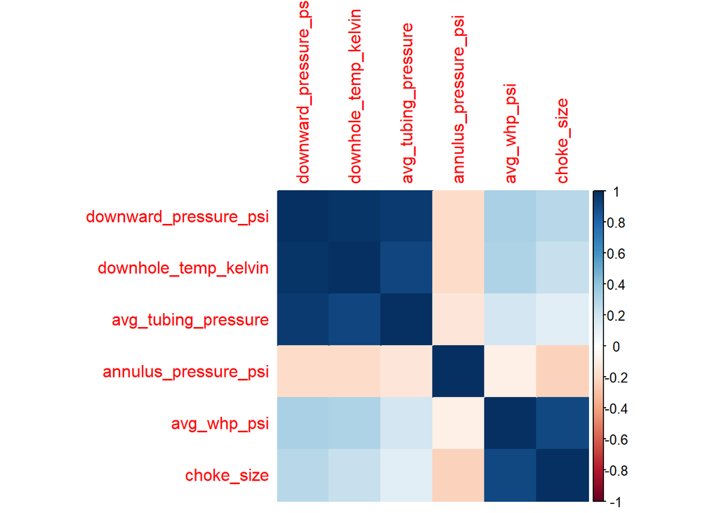

```r
# Visualize the correlation matrix
library(corrplot)
corrplot(correlation_matrix, method = "color")
```

We notice that downward_pressure_psi, downhole_temp_kelvin and avg_tubing_pressure are highly correlated amongst one another This means that when more downward pressure is applied, there is a higher downhole temperature, probably because the well digs deeper. The same applies to average tubing pressure.

Let’s Calculate the Variance Inflation Factor

```r
model <- lm(y ~ ., data = all_variables)
vif_results <- vif(model)
vif_results
```

```
##                            GVIF Df GVIF^(1/(2*Df))
## well_bore_code        22.081209  4        1.472322
## downward_pressure_psi 69.813829  1        8.355467
## downhole_temp_kelvin  63.302495  1        7.956287
## avg_tubing_pressure   18.504525  1        4.301689
## annulus_pressure_psi   2.340987  1        1.530028
## avg_whp_psi           10.345637  1        3.216463
## choke_size            11.460471  1        3.385332
## lag_y                  4.368960  1        2.090206
## days_from_origin       5.578996  1        2.361990
```

While the GVIF values are high, the adjusted GVIF value for avg_tubing pressure is less than 5. However, the values are between 5 and 10 for downhole temperature and downward pressure. This is not outrightly bad, but fitting the models again can help us detect if the model performs better if one of them is dropped

```r
model_no_downhole_temp <- lm(y ~ . - downhole_temp_kelvin + I(annulus_pressure_psi^2) + I(days_from_origin^2) + days_from_origin * well_bore_code, data = all_variables)
summary(model_no_downhole_temp)
```

```
##
## Call:
## lm(formula = y ~ . - downhole_temp_kelvin + I(annulus_pressure_psi^2) +
##     I(days_from_origin^2) + days_from_origin * well_bore_code,
##     data = all_variables)
##
## Residuals:
##      Min       1Q   Median       3Q      Max
## -25806.1   -352.6    -56.9    455.4  23741.0
##
## Coefficients:
##                                                   Estimate Std. Error t value
## (Intercept)                                     -1.940e+03  2.869e+02  -6.760
## well_bore_codeDSEAT-001-F-11 H                   3.976e+02  3.338e+02   1.191
## well_bore_codeDSEAT-001-F-12 H                   4.527e+03  3.497e+02  12.945
## well_bore_codeDSEAT-001-F-14 H                   4.623e+03  3.162e+02  14.621
## well_bore_codeDSEAT-001-F-15 D                  -1.017e+03  3.530e+02  -2.881
## downward_pressure_psi                            3.625e-01  9.957e-02   3.641
## avg_tubing_pressure                              1.258e-02  1.328e-01   0.095
## annulus_pressure_psi                             2.089e+00  1.317e+00   1.586
## avg_whp_psi                                      5.646e+00  2.840e-01  19.882
## choke_size                                      -9.500e+01  4.561e+00 -20.830
## lag_y                                            7.809e-01  6.952e-03 112.321
## days_from_origin                                -1.670e+00  9.288e-01  -1.799
## I(annulus_pressure_psi^2)                       -4.051e-03  3.055e-03  -1.326
## I(days_from_origin^2)                            6.475e-04  7.566e-05   8.557
## well_bore_codeDSEAT-001-F-11 H:days_from_origin  8.052e-01  1.046e+00   0.770
## well_bore_codeDSEAT-001-F-12 H:days_from_origin -1.799e+00  9.601e-01  -1.874
## well_bore_codeDSEAT-001-F-14 H:days_from_origin -2.417e+00  9.523e-01  -2.538
## well_bore_codeDSEAT-001-F-15 D:days_from_origin  4.443e-01  1.176e+00   0.378
##                                                 Pr(>|t|)
## (Intercept)                                      1.5e-11 ***
## well_bore_codeDSEAT-001-F-11 H                  0.233573
## well_bore_codeDSEAT-001-F-12 H                   < 2e-16 ***
## well_bore_codeDSEAT-001-F-14 H                   < 2e-16 ***
## well_bore_codeDSEAT-001-F-15 D                  0.003971 **
## downward_pressure_psi                           0.000274 ***
## avg_tubing_pressure                             0.924575
## annulus_pressure_psi                            0.112773
## avg_whp_psi                                      < 2e-16 ***
## choke_size                                       < 2e-16 ***
## lag_y                                            < 2e-16 ***
## days_from_origin                                0.072132 .
## I(annulus_pressure_psi^2)                       0.184833
## I(days_from_origin^2)                            < 2e-16 ***
## well_bore_codeDSEAT-001-F-11 H:days_from_origin 0.441599
## well_bore_codeDSEAT-001-F-12 H:days_from_origin 0.061041 .
## well_bore_codeDSEAT-001-F-14 H:days_from_origin 0.011161 *
## well_bore_codeDSEAT-001-F-15 D:days_from_origin 0.705597
## ---
## Signif. codes:  0 '***' 0.001 '**' 0.01 '*' 0.05 '.' 0.1 ' ' 1
##
## Residual standard error: 2539 on 6902 degrees of freedom
##   (5 observations deleted due to missingness)
## Multiple R-squared:  0.9193, Adjusted R-squared:  0.9191
## F-statistic:  4628 on 17 and 6902 DF,  p-value: < 2.2e-16
```

```r
model_no_downward_pressure_psi<- lm(y ~ . - downward_pressure_psi + I(annulus_pressure_psi^2) + I(days_from_origin^2) + days_from_origin * well_bore_code, data = all_variables)
summary(model_no_downward_pressure_psi)
```

```
##
## Call:
## lm(formula = y ~ . - downward_pressure_psi + I(annulus_pressure_psi^2) +
##     I(days_from_origin^2) + days_from_origin * well_bore_code,
##     data = all_variables)
##
## Residuals:
##      Min       1Q   Median       3Q      Max
## -26037.7   -404.9    -59.8    456.2  23239.8
##
## Coefficients:
##                                                   Estimate Std. Error t value
## (Intercept)                                     -1.110e+04  9.499e+02 -11.687
## well_bore_codeDSEAT-001-F-11 H                   6.201e+02  3.313e+02   1.872
## well_bore_codeDSEAT-001-F-12 H                   5.058e+03  3.512e+02  14.403
## well_bore_codeDSEAT-001-F-14 H                   4.825e+03  3.127e+02  15.428
## well_bore_codeDSEAT-001-F-15 D                  -1.240e+03  3.512e+02  -3.532
## downhole_temp_kelvin                             3.168e+01  3.159e+00  10.028
## avg_tubing_pressure                             -5.073e-01  1.120e-01  -4.531
## annulus_pressure_psi                             2.203e+00  1.299e+00   1.696
## avg_whp_psi                                      4.732e+00  2.977e-01  15.896
## choke_size                                      -7.994e+01  4.803e+00 -16.642
## lag_y                                            7.632e-01  7.165e-03 106.520
## days_from_origin                                -1.051e+00  9.248e-01  -1.137
## I(annulus_pressure_psi^2)                       -4.313e-03  3.014e-03  -1.431
## I(days_from_origin^2)                            5.663e-04  7.514e-05   7.537
## well_bore_codeDSEAT-001-F-11 H:days_from_origin -1.049e-02  1.038e+00  -0.010
## well_bore_codeDSEAT-001-F-12 H:days_from_origin -1.912e+00  9.502e-01  -2.012
## well_bore_codeDSEAT-001-F-14 H:days_from_origin -2.606e+00  9.437e-01  -2.761
## well_bore_codeDSEAT-001-F-15 D:days_from_origin  1.018e-01  1.168e+00   0.087
##                                                 Pr(>|t|)
## (Intercept)                                      < 2e-16 ***
## well_bore_codeDSEAT-001-F-11 H                  0.061267 .
## well_bore_codeDSEAT-001-F-12 H                   < 2e-16 ***
## well_bore_codeDSEAT-001-F-14 H                   < 2e-16 ***
## well_bore_codeDSEAT-001-F-15 D                  0.000416 ***
## downhole_temp_kelvin                             < 2e-16 ***
## avg_tubing_pressure                             5.96e-06 ***
## annulus_pressure_psi                            0.089859 .
## avg_whp_psi                                      < 2e-16 ***
## choke_size                                       < 2e-16 ***
## lag_y                                            < 2e-16 ***
## days_from_origin                                0.255739
## I(annulus_pressure_psi^2)                       0.152507
## I(days_from_origin^2)                           5.43e-14 ***
## well_bore_codeDSEAT-001-F-11 H:days_from_origin 0.991935
## well_bore_codeDSEAT-001-F-12 H:days_from_origin 0.044227 *
## well_bore_codeDSEAT-001-F-14 H:days_from_origin 0.005774 **
## well_bore_codeDSEAT-001-F-15 D:days_from_origin 0.930565
## ---
## Signif. codes:  0 '***' 0.001 '**' 0.01 '*' 0.05 '.' 0.1 ' ' 1
##
## Residual standard error: 2523 on 6902 degrees of freedom
##   (5 observations deleted due to missingness)
## Multiple R-squared:  0.9203, Adjusted R-squared:  0.9201
## F-statistic:  4691 on 17 and 6902 DF,  p-value: < 2.2e-16
```

In each case, the r_squared slightly reduces by removing the variables. This shows that removing either of these variables affects the performance of the model. Hence there’s good reason to keep them both

##Examining non linear relationships between numeric variables and the target